# Trump versus…

Estimating head-to-head matchups using polling averages

peter phalen

March 10, 2020

There is quite a bit of polling data on head-to-head matchups between candidates: “If you had to choose between candidate X or candidate Y, who would you vote for?”

In this post we’ll use polling data compiled by [538](https://fivethirtyeight.com/) to look at how Bernie Sanders is doing head-to-head against Trump, and then compare that to Biden’s performance. We’ll adjust our polling average for “house effects”, which are systematic tendencies for polling firms to favor a particular candidate.

Overall, the data suggest that both Sanders and Biden outperform Trump. Early in the campaign, Biden was performing better against Trump than Sanders, but that’s no longer the case.

```r
library(tidyverse)
library(rstanarm)
library(gridExtra)
options(mc.cores = parallel::detectCores())
```

#### Preliminary data prep

We get the raw data directly from fivethirtyeight, and then process it.

```r
data <- read_csv("https://projects.fivethirtyeight.com/polls-page/president_polls.csv")

data <-
  data %>%
  subset(is.na(state))  # national polls only

data$candidate_name <- factor(data$candidate_name)

# encode dates as... dates
data <- data %>%
  transform(start_date = as.Date(data$start_date, format = "%m/%d/%y"),
         end_date = as.Date(data$end_date, format = "%m/%d/%y"))

# polls are usually conducted over multiple days %>%
# get the point midway between the start and end dates of each poll
data$date <- data$start_date + floor((data$end_date-data$start_date)/2)

#convert date to a numeric variable (we'll use this later for modeling)
data$julian <- scale(julian(data$date))
```

# Bernie Sanders versus Trump

We’ll start by looking at Sanders versus Trump, restricting the dataset to the relevant polls.

```r
# get sanders head-to-heads
sanders_rows <- which(data$candidate_name == "Bernard Sanders")
sanders_rows <- lapply(sanders_rows, function(x){seq(x, x + 1)})
sanders_rows <- do.call("c", sanders_rows)
sanders_v <- data[sanders_rows,]

# get rid of minor candidates
pence_rows <- which(sanders_v$candidate_name == "Mike Pence")
sanders_v_pence_rows <- c(pence_rows, pence_rows - 1)
sanders_v <- sanders_v %>% slice(-sanders_v_pence_rows)

haley_rows <- which(sanders_v$candidate_name == "Nimrata R. Haley")
sanders_v_haley_rows <- c(haley_rows, haley_rows - 1)
sanders_v <- sanders_v %>% slice(-sanders_v_haley_rows)

# also get a data frame for just Bernie's vote share
bern <- sanders_v %>% subset(candidate_name == "Bernard Sanders")
# and then Trump's
trump.b <- sanders_v %>% subset(candidate_name == "Donald Trump")
```

First we’ll plot the data to get a rough idea for how Bernie is doing.

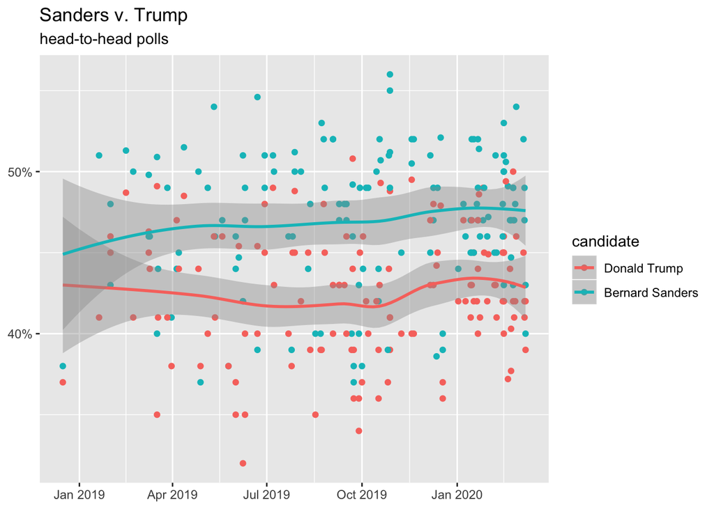

```r
sanders_v %>%
  # relevel just for the color scheme
  transform(candidate = relevel(candidate_name, ref="Donald Trump")) %>%
  ggplot() +
  aes(x = date, y = pct, color = candidate) +
  geom_point() +
  ggtitle("Sanders v. Trump", subtitle="head-to-head polls") +
  geom_smooth() +
  theme(axis.title=element_blank()) +
  scale_y_continuous(labels=function(x){paste0(x,"%")})
```

#### House effects

These polls are conducted by various polling firms. Polling firms tend to have biases, if only due to methodological differences. It’s worth checking for these so-called “house effects”–we plot each poll by agency here.

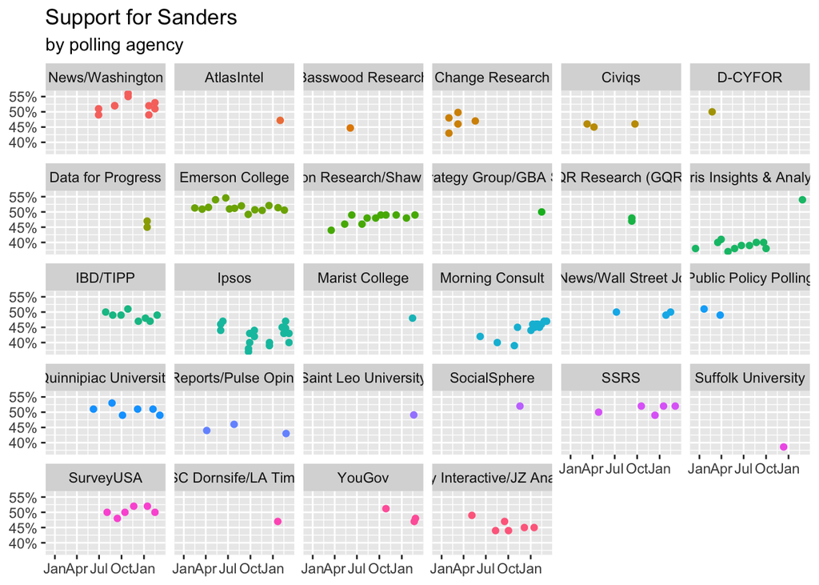

```r
bern %>%
  ggplot() +
  aes(x = date, y = pct, color=pollster) +
  geom_point() +
  ggtitle("Support for Sanders", subtitle="by polling agency") +
  theme(legend.position = "none") +
  theme(axis.title=element_blank()) +
  scale_y_continuous(labels=function(x){paste0(x,"%")}) +
  scale_x_date(date_labels="%b") +
  facet_wrap(~pollster, scales = "fixed")
```

House effects are clearly visible in these graphs. For example, Emerson College shows consistently better results for Bernie Sanders than Fox News does over the same period of time.

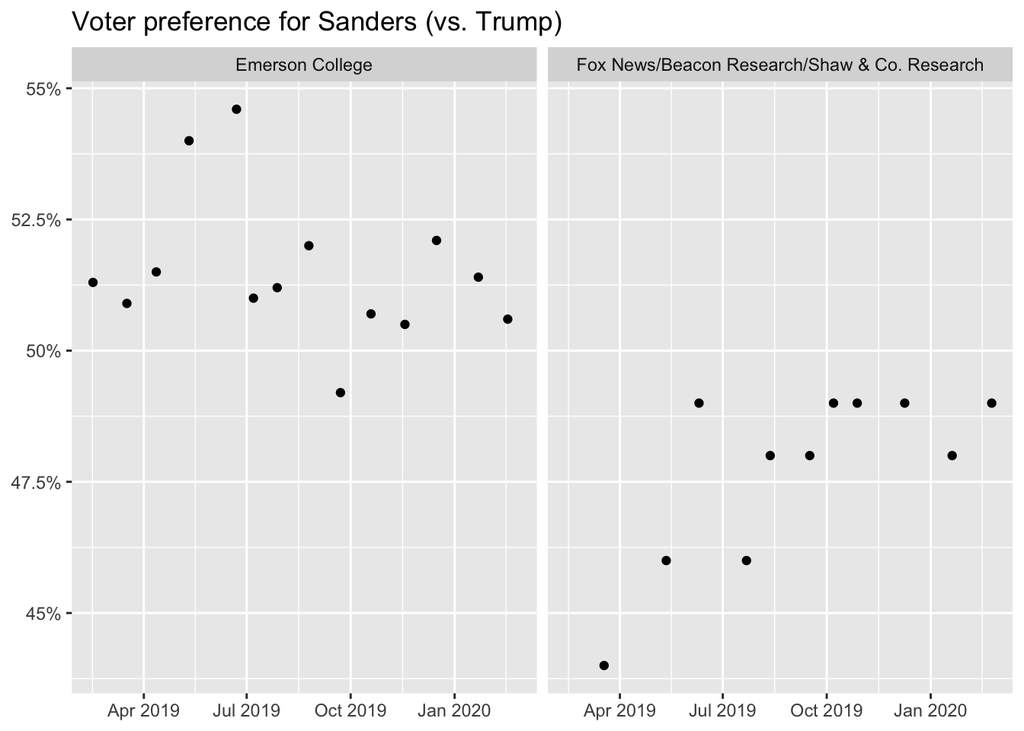

```r
bern %>%
  subset(pollster %in% c("Fox News/Beacon Research/Shaw & Co. Research",
                         "Emerson College")) %>%
  ggplot() +
  aes(x = date, y = pct) +
  geom_point() +
  ggtitle("Voter preference for Sanders (vs. Trump)") +
  theme(legend.position = "none") +
  theme(axis.title=element_blank()) +
  scale_y_continuous(labels=function(x){paste0(x,"%")}) +
  facet_wrap(~pollster, scales = "fixed")
```

House effects like these lead us to *under*estimate the degree of uncertainty in the data. We’ll want to account for them in our model.

### Adjusting for house effects

We’ll use Stan to specify a simple model of the Bernie versus Trump matchup that takes house effects into account.

```r
fit.bernie <- stan_gamm4(pct ~ s(julian), random=~(1|pollster), data=bern, refresh=0)
fit.trump.b <- stan_gamm4(pct ~ s(julian), random=~(1|pollster), data=trump.b, refresh=0)
```

We’ll use the model to plot voter preferences for Bernie over Trump, adjusting for the above house effects.

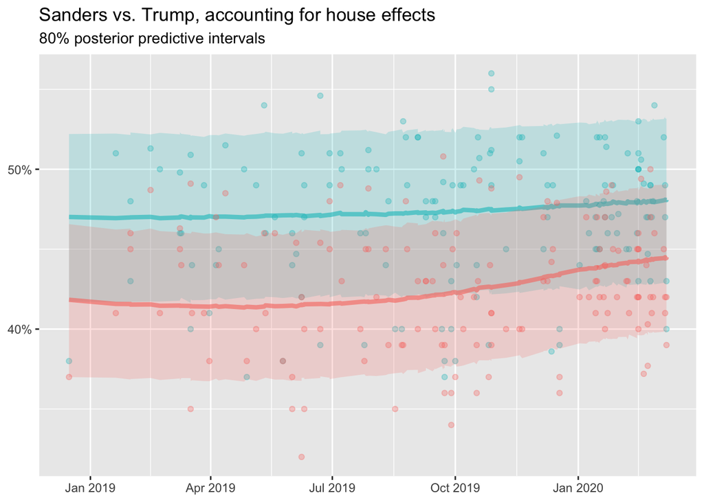

```r
bern.pred.frame <- bern %>% transform(pollster = 0)
bern.draws <- posterior_predict(fit.bernie, newdata=bern.pred.frame,
                                    re.form = NULL)
bern.ests <- apply(bern.draws, 2, mean)
# get 80% posterior intervals
bern.PIs <- t(apply(bern.draws, 2, function(x){quantile(x, probs=c(.1,.9))}))
bernie.out <- cbind(bern, Estimate = bern.ests,
                    Q10 = bern.PIs[,"10%"], Q90 = bern.PIs[,"90%"])


trump.b.pred.frame <- trump.b %>% transform(pollster = 0)
trump.b.draws <- posterior_predict(fit.trump.b, newdata=trump.b.pred.frame,
                                re.form = NULL)

trump.b.ests <- apply(trump.b.draws, 2, mean)
# get 80% posterior intervals
trump.b.PIs <- t(apply(trump.b.draws, 2, function(x){quantile(x, probs=c(.1,.9))}))
trump.b.out <- cbind(trump.b, Estimate = trump.b.ests,
                     Q10 = trump.b.PIs[,"10%"], Q90 = trump.b.PIs[,"90%"])

dem.col <- "#00BFC4"
trump.col <- "#F8766D"

# plot trump and bernie models together
bern.figure <-
  ggplot(bernie.out) +
  aes(x = date, y = pct) +
  theme(axis.title=element_blank()) +
  scale_y_continuous(labels=function(x){paste0(x,"%")}) +
  ggtitle("Sanders vs. Trump, accounting for house effects", subtitle = "80% posterior predictive intervals") +
  #plot Bernie's share of the vote
  geom_point(color=dem.col, alpha=.3) +
  geom_ribbon(aes(ymin=Q10, ymax=Q90), fill=dem.col, alpha=.2) +
  geom_line(aes(y = Estimate), color = dem.col, size=1.5, alpha=.6) +
  #now plot Trump's share
  geom_point(data=trump.b.out,  aes(x = date, y = pct), color=trump.col, alpha=.3) +
  geom_ribbon(data=trump.b.out, aes(ymin=Q10, ymax=Q90), fill=trump.col, alpha=.2) +
  geom_line(data=trump.b.out, aes(y = Estimate), color = trump.col, size=1.5, alpha=.6)
bern.figure
```

# Joe Biden versus Trump

Now we’ll do the same thing for Biden.

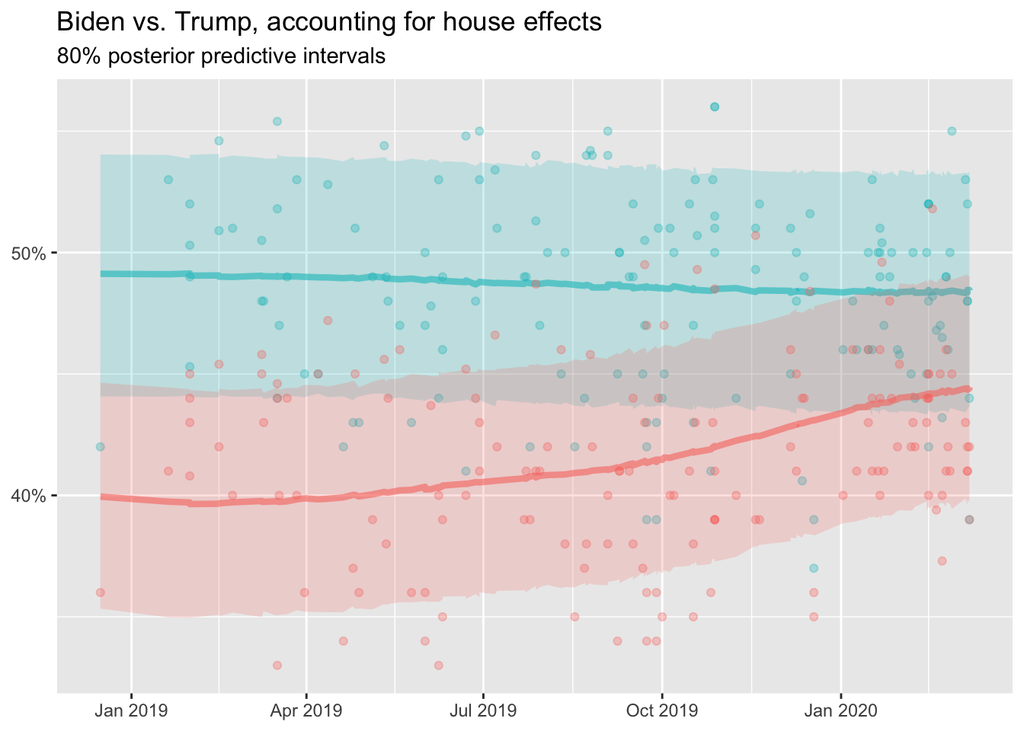

```r
# get biden head-to-heads
joe_rows <- which(data$candidate_name == "Joseph R. Biden Jr.")
joe_rows <- lapply(joe_rows, function(x){seq(x, x + 1)})
joe_rows <- do.call("c", joe_rows)
joe_v <- data[joe_rows,]

# get rid of minor candidates
pence_rows <- which(joe_v$candidate_name == "Mike Pence")
joe_v_pence_rows <- c(pence_rows, pence_rows - 1)
joe_v <- joe_v %>% slice(-joe_v_pence_rows)

haley_rows <- which(joe_v$candidate_name == "Nimrata R. Haley")
joe_v_haley_rows <- c(haley_rows, haley_rows - 1)
joe_v <- joe_v %>% slice(-joe_v_haley_rows)

# also get a data frame for just Biden's vote share
joe <- joe_v %>% subset(candidate_name == "Joseph R. Biden Jr.")
# and then Trump's
trump.j <- joe_v %>% subset(candidate_name == "Donald Trump")

fit.joe <- stan_gamm4(pct ~ s(julian), random=~(1|pollster), data=joe, refresh=0)
fit.trump.j <- stan_gamm4(pct ~ s(julian), random=~(1|pollster), data=trump.j, refresh=0)

joe.pred.frame <- joe %>% transform(pollster = 0)
joe.draws <- posterior_predict(fit.joe, newdata=joe.pred.frame,
                                re.form = NULL)
joe.ests <- apply(joe.draws, 2, mean)
# get 80% posterior intervals
joe.PIs <- t(apply(joe.draws, 2, function(x){quantile(x, probs=c(.1,.9))}))
joe.out <- cbind(joe, Estimate = joe.ests,
                 Q10 = joe.PIs[,"10%"], Q90 = joe.PIs[,"90%"])


trump.j.pred.frame <- trump.j %>% transform(pollster = 0)
trump.j.draws <- posterior_predict(fit.trump.j, newdata=trump.j.pred.frame,
                                   re.form = NULL)

trump.j.ests <- apply(trump.j.draws, 2, mean)
# get 80% posterior intervals
trump.j.PIs <- t(apply(trump.j.draws, 2, function(x){quantile(x, probs=c(.1,.9))}))
trump.j.out <- cbind(trump.j, Estimate = trump.j.ests,
                     Q10 = trump.j.PIs[,"10%"], Q90 = trump.j.PIs[,"90%"])


# plot trump and biden models together
joe.figure <-
  ggplot(joe.out) +
  aes(x = date, y = pct) +
  theme(axis.title=element_blank()) +
  scale_y_continuous(labels=function(x){paste0(x,"%")}) +
  ggtitle("Biden vs. Trump, accounting for house effects", subtitle = "80% posterior predictive intervals") +
  #plot biden's share of the vote
  geom_point(color=dem.col, alpha=.3) +
  geom_ribbon(aes(ymin=Q10, ymax=Q90), fill=dem.col, alpha=.2) +
  geom_line(aes(y = Estimate), color = dem.col, size=1.5, alpha=.6) +
  #now plot Trump's share
  geom_point(data=trump.j.out,  aes(x = date, y = pct), color=trump.col, alpha=.3) +
  geom_ribbon(data=trump.j.out, aes(ymin=Q10, ymax=Q90), fill=trump.col, alpha=.2) +
  geom_line(data=trump.j.out, aes(y = Estimate), color = trump.col, size=1.5, alpha=.6)
joe.figure
```

A year ago, Biden was performing better than Bernie Sanders against Trump. That’s no longer true.

Here are the two candidates’ trajectories side-by-side for easier comparison.

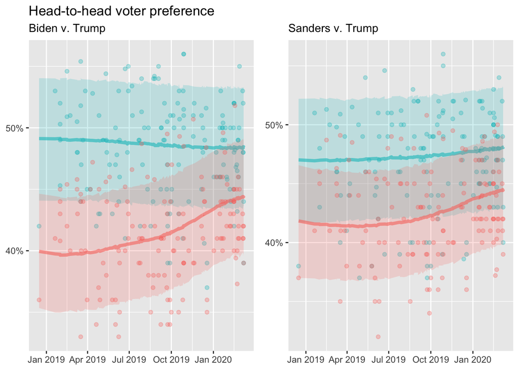

```r
ylo <- 32; yhi <- 56
grid.arrange(joe.figure + ylim(ylo, yhi) +
                 theme(axis.title.y=element_blank()) +
                 scale_y_continuous(labels=function(x){paste0(x,"%")}) +
                 ggtitle("Head-to-head voter preference", subtitle="Biden v. Trump"),
             bern.figure + ylim(ylo, yhi) +
                 theme(axis.title.y=element_blank()) +
                 scale_y_continuous(labels=function(x){paste0(x,"%")}) +
                 ggtitle("", "Sanders v. Trump"),
             nrow=1)
```